# APLS study

Total mothers

```
## [1] 92
```

| total_pregnancies |
| --- |
| 373 |

Checking for clinical criteria

| criterion | n |
| --- | --- |
| 1 | 64 |
| 2 | 1 |
| 3 | 14 |
| no | 13 |

After correcting for criteria

[output not shown]

```
##   Aspirin_only LMWH_only Either None Both Aspirin LMWH
## 1           25         9     68  249   34      59   43
```

demography

number of pregnancies

```
##   0%  25%  50%  75% 100%
##    1    3    4    5    9
```

PIH

```
##   PIH percent - out of pregnancies
## 1  17                     5.362776
```

Other Medical conditions

| condition | n | percent - out of mothers |
| --- | --- | --- |
| Hypothyroidism | 2 | 2.173913 |

Investigations Any of the 5 investigations

| Any investigation | precent - of mothers |
| --- | --- |
| 26 | 32.91139 |

Any of Lupus, APLS, cardiolipin, beta2

Proportion of a positive result

| Any investigation out of Lupus, cardio, beta, APLS | precent - of mothers |
| --- | --- |
| 25 | 31.64557 |

| positive subjects | percent of tested |
| --- | --- |
| 11 | 44 |

Previous pregnancy outcome without specific treatment

| Total | Successful | failed.pregnancies | success.rate | MC.before.10.wk | MC.at.or.after.10.wk |
| --- | --- | --- | --- | --- | --- |
| 249 | 37 | 212 | 14.85944 | 90 | 113 |

Previous pregnancy outcome - Treated by either Aspirin or LMWH

| total.pregnancies | successful.pregnancies | failed.pregnancies | success.rate | MC.before.10.wk | MC.at.or.after.10.wk |
| --- | --- | --- | --- | --- | --- |
| 68 | 33 | 35 | 48.52941 | 6 | 28 |

Previous pregnancy outcome - Treated Aspirin and LMWH

| total.pregnancies | successful.pregnancies | failed.pregnancies | success.rate | MC.before.10.wk | MC.at.or.after.10.wk |
| --- | --- | --- | --- | --- | --- |
| 34 | 23 | 11 | 67.64706 | 3 | 7 |

Previous pregnancy outcome - Treated Aspirin alone

| total.pregnancies | successful.pregnancies | failed.pregnancies | success.rate | MC.before.10.wk | MC.at.or.after.10.wk |
| --- | --- | --- | --- | --- | --- |
| 25 | 5 | 20 | 20 | 3 | 17 |

Previous pregnancy outcome - Treated LMWH alone

| total.pregnancies | successful.pregnancies | failed.pregnancies | success.rate | MC.before.10.wk | MC.at.or.after.10.wk |
| --- | --- | --- | --- | --- | --- |
| 9 | 5 | 4 | 55.55556 | 0 | 4 |

comparison

No treatment vs any

```
## # A tibble: 1 x 9
##   estimate1 estimate2 statistic p.value parameter conf.low conf.high method
##       <dbl>     <dbl>     <dbl>   <dbl>     <dbl>    <dbl>     <dbl> <chr>
## 1     0.485     0.149      33.3 4.02e-9         1    0.221         1 2-sam~
## # ... with 1 more variable: alternative <chr>
```

No treatment vs both

```
## # A tibble: 1 x 9
##   estimate1 estimate2 statistic  p.value parameter conf.low conf.high method
##       <dbl>     <dbl>     <dbl>    <dbl>     <dbl>    <dbl>     <dbl> <chr>
## 1     0.676     0.149      46.8 3.96e-12         1    0.374         1 2-sam~
## # ... with 1 more variable: alternative <chr>
```

No treatment vs asp

```
## # A tibble: 1 x 9
##   estimate1 estimate2 statistic p.value parameter conf.low conf.high method
##       <dbl>     <dbl>     <dbl>   <dbl>     <dbl>    <dbl>     <dbl> <chr>
## 1       0.2     0.149     0.151   0.349         1   -0.107         1 2-sam~
## # ... with 1 more variable: alternative <chr>
```

No treatment vs LMWH

```
## # A tibble: 1 x 9
##   estimate1 estimate2 statistic p.value parameter conf.low conf.high method
##       <dbl>     <dbl>     <dbl>   <dbl>     <dbl>    <dbl>     <dbl> <chr>
## 1     0.556     0.149      7.78 0.00264         1   0.0744         1 2-sam~
## # ... with 1 more variable: alternative <chr>
```

ASP treatment vs LMWH

```
## # A tibble: 1 x 9
##   estimate1 estimate2 statistic p.value parameter conf.low conf.high method
##       <dbl>     <dbl>     <dbl>   <dbl>     <dbl>    <dbl>     <dbl> <chr>
## 1     0.556       0.2      2.50   0.114         1  -0.0805     0.792 2-sam~
## # ... with 1 more variable: alternative <chr>
```

ASP treatment vs both

```
## # A tibble: 1 x 9
##   estimate1 estimate2 statistic p.value parameter conf.low conf.high method
##       <dbl>     <dbl>     <dbl>   <dbl>     <dbl>    <dbl>     <dbl> <chr>
## 1     0.676       0.2      11.3 3.93e-4         1    0.255         1 2-sam~
## # ... with 1 more variable: alternative <chr>
```

LMWH treatment vs both

```
## # A tibble: 1 x 9
##   estimate1 estimate2 statistic p.value parameter conf.low conf.high method
##       <dbl>     <dbl>     <dbl>   <dbl>     <dbl>    <dbl>     <dbl> <chr>
## 1     0.676     0.556    0.0804   0.388         1   -0.252         1 2-sam~
## # ... with 1 more variable: alternative <chr>
```

#### results

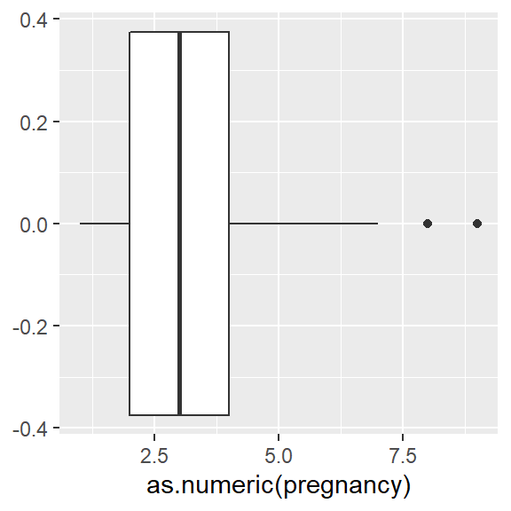

The mean age of the selected mothers was 32.2051282 with a standard deviation of 5.1278688.

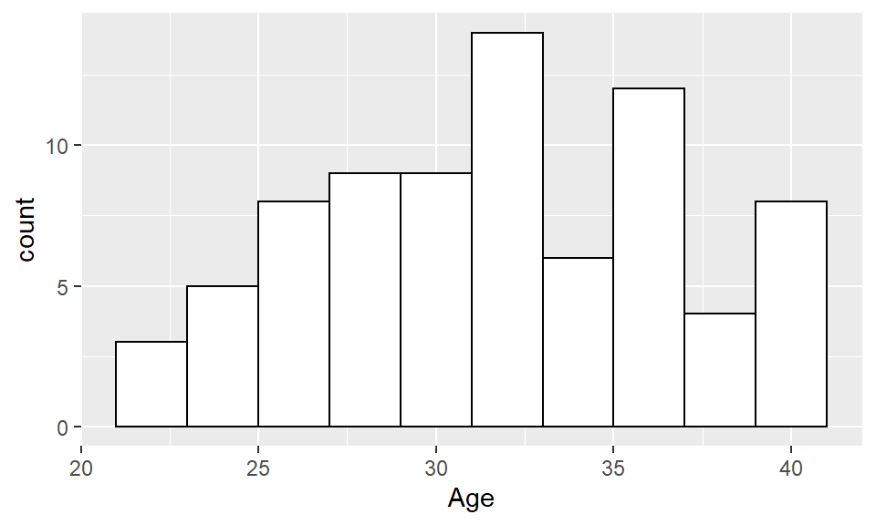

34 pregnancies were treated with both LMWH and aspirin. 25 and 9 pregnancies were treated with aspirin alone and LMWH alone, respectively.

17 pregnancies were complicated with PIH.

| PIH | percent - out of pregnancies |
| --- | --- |
| 17 | 5.362776 |

Outcome by treatment group

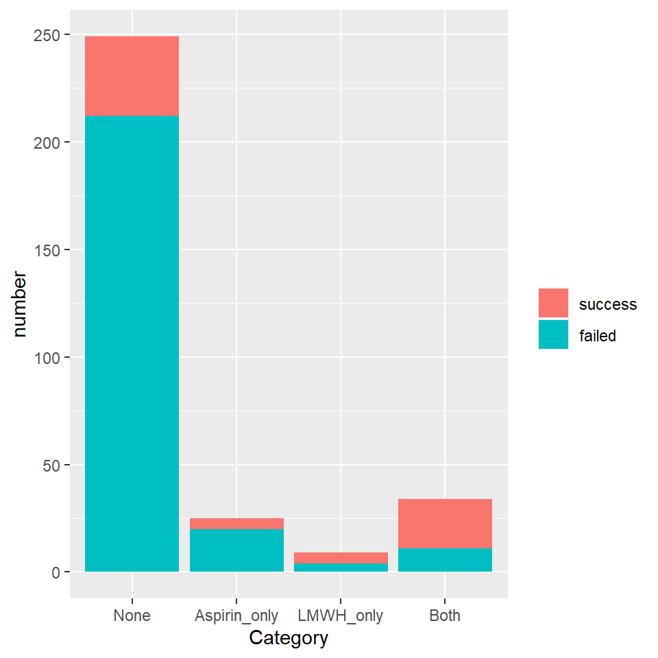

The rate of live births among mothers who were not received specific treatment for APS was 0.1485944. In contrast, 68 gestations were treated with either aspirin, LMWH or both and the rate of successful outcome was 0.4852941

Outcome in each group is summarized below

| Category | n | live births | live birth rate |
| --- | --- | --- | --- |
| None | 249 | 37 | 14.85944 |
| Aspirin only | 25 | 5 | 20.00000 |
| LMWH only | 9 | 5 | 55.55556 |
| Both | 34 | 23 | 67.64706 |

Investigations  
25 (31.6455696%) mothers had undergone any of antibody tests for APL and out of them, 11 (44%) yeilded a positive result.

| Lupus | cardiolipin | beta 2 microglobulin | APL |
| --- | --- | --- | --- |
| 22 | 19 | 5 | 6 |

Live rates between test positives and negatives

Number of pregnancies that were treated, in mothers who were tested for antibodies was 19. Out of them, 10 (52.6315789%) mothers tested positive for at least one test and the success rate was 0.2. 9 (47.3684211%) mothers had negative results and success rate among them was 0.2222222